# Goal

Using the data collected from existing customers, build a model that will help the marketing team identify potential customers who are relatively more likely to subscribe term deposit and thus increase their hit ratio.

## Deliverable – 1 (Exploratory data quality report reflecting the following) – (20)

### Univariate analysis (12 marks)

#### Univariate analysis – data types and description of the independent attributes which should include (name, meaning, range of values observed, central values (mean and median), standard deviation and quartiles, analysis of the body of distributions / tails, missing values, outliers.

```python
import warnings
warnings.filterwarnings('ignore')
import numpy as np
import pandas as pd

import matplotlib.pyplot as plt
%matplotlib inline
import seaborn as sns

from sklearn.model_selection import train_test_split
from sklearn.tree import DecisionTreeClassifier
from sklearn.metrics import confusion_matrix, recall_score, precision_score, f1_score, roc_auc_score,accuracy_score
from sklearn.linear_model import LogisticRegression

from yellowbrick.classifier import ClassificationReport, ROCAUC
```

```python
df_in = pd.read_csv('bank-full.csv')
df=df_in.copy()
df.head(10)
```

|  | age | job | marital | education | default | balance | housing | loan | contact | day | month | duration | campaign | pdays | previous | poutcome | Target |
| --- | --- | --- | --- | --- | --- | --- | --- | --- | --- | --- | --- | --- | --- | --- | --- | --- | --- |
| 0 | 58 | management | married | tertiary | no | 2143 | yes | no | unknown | 5 | may | 261 | 1 | -1 | 0 | unknown | no |
| 1 | 44 | technician | single | secondary | no | 29 | yes | no | unknown | 5 | may | 151 | 1 | -1 | 0 | unknown | no |
| 2 | 33 | entrepreneur | married | secondary | no | 2 | yes | yes | unknown | 5 | may | 76 | 1 | -1 | 0 | unknown | no |
| 3 | 47 | blue-collar | married | unknown | no | 1506 | yes | no | unknown | 5 | may | 92 | 1 | -1 | 0 | unknown | no |
| 4 | 33 | unknown | single | unknown | no | 1 | no | no | unknown | 5 | may | 198 | 1 | -1 | 0 | unknown | no |
| 5 | 35 | management | married | tertiary | no | 231 | yes | no | unknown | 5 | may | 139 | 1 | -1 | 0 | unknown | no |
| 6 | 28 | management | single | tertiary | no | 447 | yes | yes | unknown | 5 | may | 217 | 1 | -1 | 0 | unknown | no |
| 7 | 42 | entrepreneur | divorced | tertiary | yes | 2 | yes | no | unknown | 5 | may | 380 | 1 | -1 | 0 | unknown | no |
| 8 | 58 | retired | married | primary | no | 121 | yes | no | unknown | 5 | may | 50 | 1 | -1 | 0 | unknown | no |
| 9 | 43 | technician | single | secondary | no | 593 | yes | no | unknown | 5 | may | 55 | 1 | -1 | 0 | unknown | no |

```python
df.dtypes
```

```
age           int64
job          object
marital      object
education    object
default      object
balance       int64
housing      object
loan         object
contact      object
day           int64
month        object
duration      int64
campaign      int64
pdays         int64
previous      int64
poutcome     object
Target       object
dtype: object
```

```python
print('number of rows and columns in data is:',df.shape)
```

```
number of rows and columns in data is: (45211, 17)
```

```python
df.describe().transpose()
```

|  | count | mean | std | min | 25% | 50% | 75% | max |
| --- | --- | --- | --- | --- | --- | --- | --- | --- |
| age | 45211.0 | 40.936210 | 10.618762 | 18.0 | 33.0 | 39.0 | 48.0 | 95.0 |
| balance | 45211.0 | 1362.272058 | 3044.765829 | -8019.0 | 72.0 | 448.0 | 1428.0 | 102127.0 |
| day | 45211.0 | 15.806419 | 8.322476 | 1.0 | 8.0 | 16.0 | 21.0 | 31.0 |
| duration | 45211.0 | 258.163080 | 257.527812 | 0.0 | 103.0 | 180.0 | 319.0 | 4918.0 |
| campaign | 45211.0 | 2.763841 | 3.098021 | 1.0 | 1.0 | 2.0 | 3.0 | 63.0 |
| pdays | 45211.0 | 40.197828 | 100.128746 | -1.0 | -1.0 | -1.0 | -1.0 | 871.0 |
| previous | 45211.0 | 0.580323 | 2.303441 | 0.0 | 0.0 | 0.0 | 0.0 | 275.0 |

### Summary:

There are negative balance and pdays which are meaningful according to project description.Negative balance means they have to pay back for the accont. The std deviation of mean balance is very high saying data heavily distributed. There is max 4918s for a call that might be outlier or 63 times the campaingn reach out a client which might be an outlier too.

```python
df.info()
```

```
<class 'pandas.core.frame.DataFrame'>
RangeIndex: 45211 entries, 0 to 45210
Data columns (total 17 columns):
 #   Column     Non-Null Count  Dtype
---  ------     --------------  -----
 0   age        45211 non-null  int64
 1   job        45211 non-null  object
 2   marital    45211 non-null  object
 3   education  45211 non-null  object
 4   default    45211 non-null  object
 5   balance    45211 non-null  int64
 6   housing    45211 non-null  object
 7   loan       45211 non-null  object
 8   contact    45211 non-null  object
 9   day        45211 non-null  int64
 10  month      45211 non-null  object
 11  duration   45211 non-null  int64
 12  campaign   45211 non-null  int64
 13  pdays      45211 non-null  int64
 14  previous   45211 non-null  int64
 15  poutcome   45211 non-null  object
 16  Target     45211 non-null  object
dtypes: int64(7), object(10)
memory usage: 5.9+ MB
```

```python
df.isnull().sum()
```

```
age          0
job          0
marital      0
education    0
default      0
balance      0
housing      0
loan         0
contact      0
day          0
month        0
duration     0
campaign     0
pdays        0
previous     0
poutcome     0
Target       0
dtype: int64
```

There is no null values in the data

```python
(#data imputaion check for zeros
(df==0).sum(axis=0))
```

```
age              0
job              0
marital          0
education        0
default          0
balance       3514
housing          0
loan             0
contact          0
day              0
month            0
duration         3
campaign         0
pdays            0
previous     36954
poutcome         0
Target           0
dtype: int64
```

There are 3514 cleints with zero balance. There 3 last contact duration which are zeroand 36954 number of clients have not been contacted which is quiet a large number. number of zero looks relavent we don't do imputation

```python
#data imputaion check for negatives
(df[df.columns[df.dtypes=='int64']]<0).sum(axis=0)
```

```
age             0
balance      3766
day             0
duration        0
campaign        0
pdays       36954
previous        0
dtype: int64
```

The pdays negative is saying 36954 of clients has not been contacted. This is highly correlated with the number of zeros in previous column which says the number of times 36954 clients has been contated is zero for similar number.

```python
df.nunique() # Number of unique values in a column
```

```
age            77
job            12
marital         3
education       4
default         2
balance      7168
housing         2
loan            2
contact         3
day            31
month          12
duration     1573
campaign       48
pdays         559
previous       41
poutcome        4
Target          2
dtype: int64
```

```python
for i in df.columns[df.dtypes=='object']:
    df[i]=df[i].astype('category')
df.info()
```

```
<class 'pandas.core.frame.DataFrame'>
RangeIndex: 45211 entries, 0 to 45210
Data columns (total 17 columns):
 #   Column     Non-Null Count  Dtype
---  ------     --------------  -----
 0   age        45211 non-null  int64
 1   job        45211 non-null  category
 2   marital    45211 non-null  category
 3   education  45211 non-null  category
 4   default    45211 non-null  category
 5   balance    45211 non-null  int64
 6   housing    45211 non-null  category
 7   loan       45211 non-null  category
 8   contact    45211 non-null  category
 9   day        45211 non-null  int64
 10  month      45211 non-null  category
 11  duration   45211 non-null  int64
 12  campaign   45211 non-null  int64
 13  pdays      45211 non-null  int64
 14  previous   45211 non-null  int64
 15  poutcome   45211 non-null  category
 16  Target     45211 non-null  category
dtypes: category(10), int64(7)
memory usage: 2.8 MB
```

```python
for i in list(df.columns[df.dtypes=='category']):
    print(df[i].value_counts(normalize=True))
```

```
blue-collar      0.215257
management       0.209197
technician       0.168034
admin.           0.114375
services         0.091880
retired          0.050076
self-employed    0.034925
entrepreneur     0.032890
unemployed       0.028820
housemaid        0.027427
student          0.020747
unknown          0.006370
Name: job, dtype: float64
married     0.601933
single      0.282896
divorced    0.115171
Name: marital, dtype: float64
secondary    0.513194
tertiary     0.294198
primary      0.151534
unknown      0.041074
Name: education, dtype: float64
no     0.981973
yes    0.018027
Name: default, dtype: float64
yes    0.555838
no     0.444162
Name: housing, dtype: float64
no     0.839774
yes    0.160226
Name: loan, dtype: float64
cellular     0.647741
unknown      0.287983
telephone    0.064276
Name: contact, dtype: float64
may    0.304483
jul    0.152507
aug    0.138174
jun    0.118135
nov    0.087810
apr    0.064851
feb    0.058592
jan    0.031032
oct    0.016323
sep    0.012807
mar    0.010551
dec    0.004733
Name: month, dtype: float64
unknown    0.817478
failure    0.108403
other      0.040698
success    0.033421
Name: poutcome, dtype: float64
no     0.883015
yes    0.116985
Name: Target, dtype: float64
```

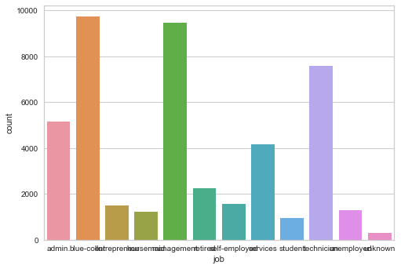

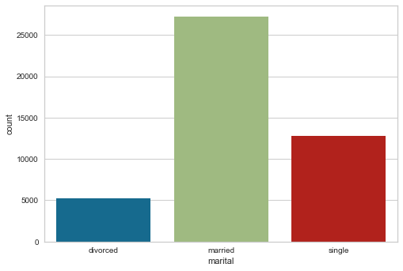

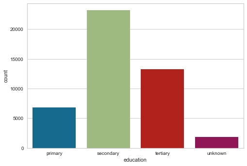

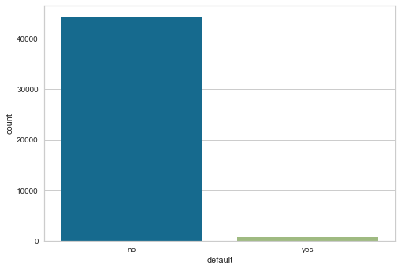

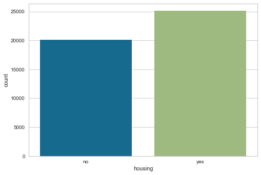

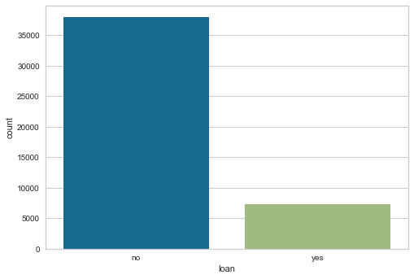

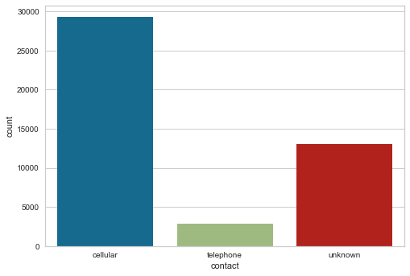

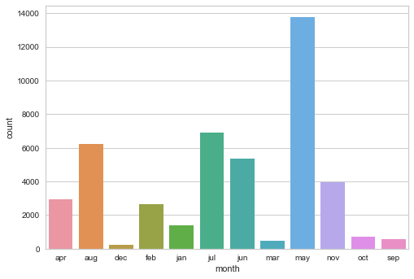

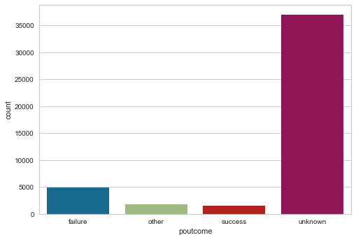

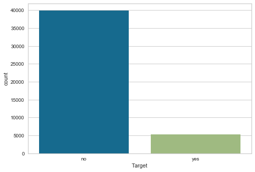

```python
#we use countplot for categorical object
for i in df.columns[df.dtypes=='category']:
    sns.countplot(df[i],orient="v")
    plt.show()
```

from the countplots we can see for example the majority of the clients are married or have secondary education.

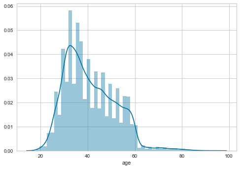

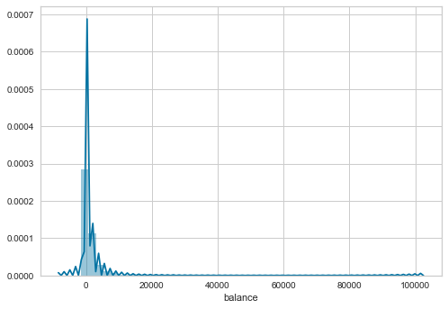

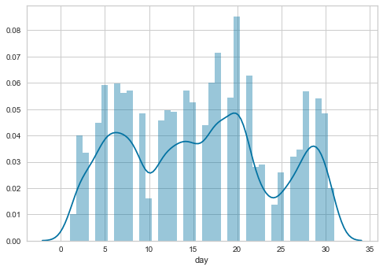

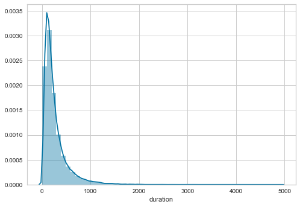

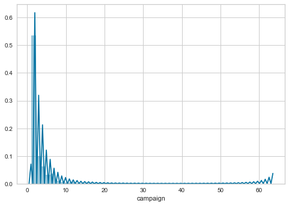

```python
#we use distplot for numeric data

for i in ['age','balance','day','duration','campaign']:
    sns.distplot(df[i])
    plt.show()
```

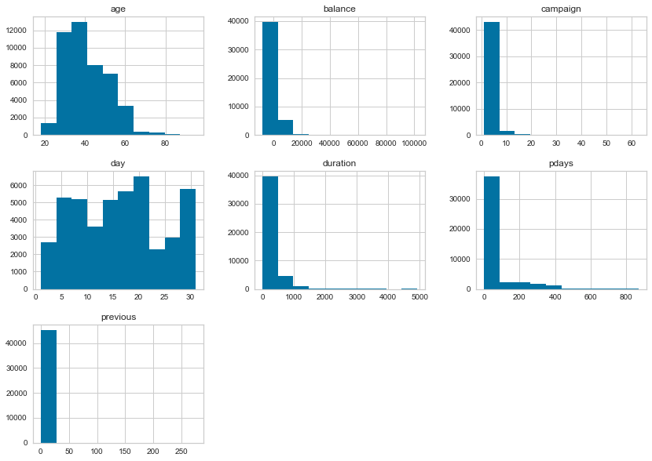

```python
df.hist(bins=10, figsize=(14,10))
plt.show()
```

# Multivariate analysis (8 marks)

In this part the idea is to understand the relation between dataset.

```python
# We look at the target column to understand how the data is distributed amongst the various values
df.groupby(["Target"]).mean()
```

| Target | age | balance | day | duration | campaign | pdays | previous |
| --- | --- | --- | --- | --- | --- | --- | --- |
| no | 40.838986 | 1303.714969 | 15.892290 | 221.182806 | 2.846350 | 36.421372 | 0.502154 |
| yes | 41.670070 | 1804.267915 | 15.158253 | 537.294574 | 2.141047 | 68.702968 | 1.170354 |

```python
df.groupby(["Target"]).median()
```

| Target | age | balance | day | duration | campaign | pdays | previous |
| --- | --- | --- | --- | --- | --- | --- | --- |
| no | 39 | 417 | 16 | 164 | 2 | -1 | 0 |
| yes | 38 | 733 | 15 | 426 | 2 | -1 | 0 |

The table shows duration or pdays is higher in accpeted deposit.

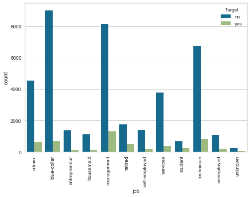

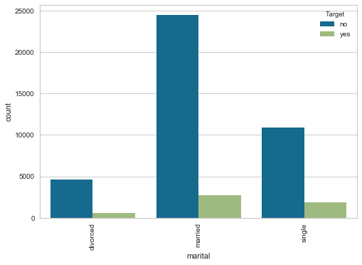

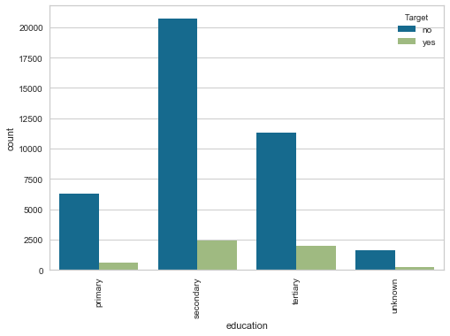

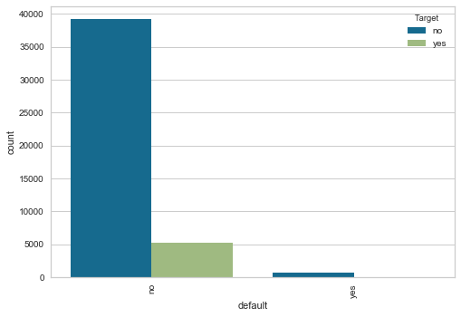

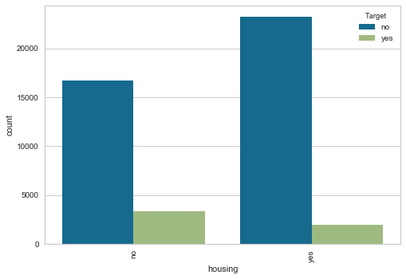

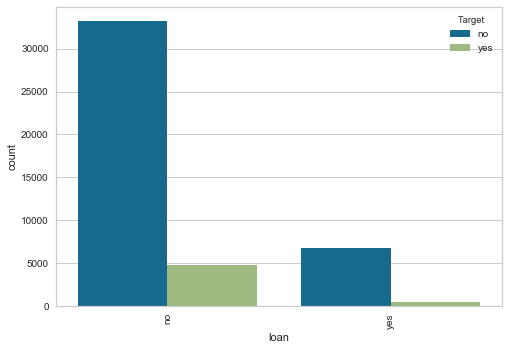

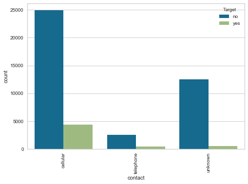

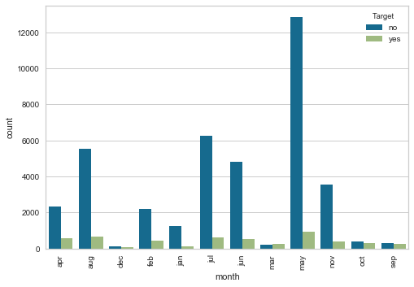

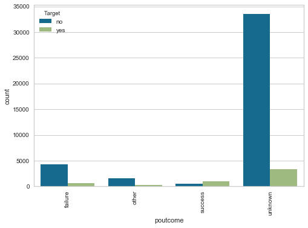

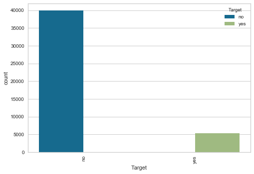

```python
plt.figsize=(14,10)
for i in df.columns[df.dtypes=='category']:
    sns.countplot(x = i,data=df,hue='Target')
# it plots a barplot where y axis shows the count of each category and here 'hue' is used to represent diffrenent class of target
    plt.xticks(rotation=90) # to rotate labels of x-axis
    plt.show()
```

By these plots we try to find out if Target is observed higher in specefic category. For example management jobs or higher education (category 3) have more chance to client subscribed a term deposit. But these values are also in general high compared to other varables in the specific category. we need to check some othe plots and correlation.

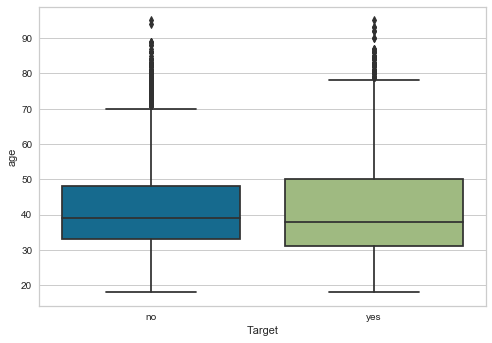

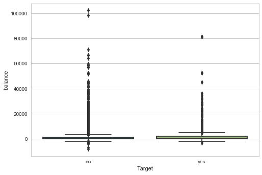

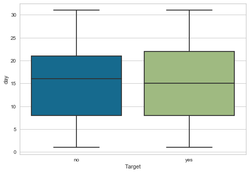

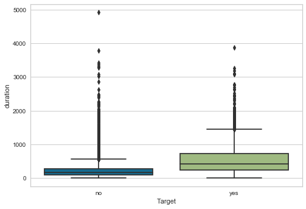

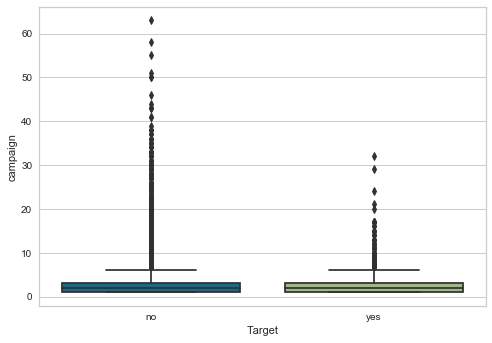

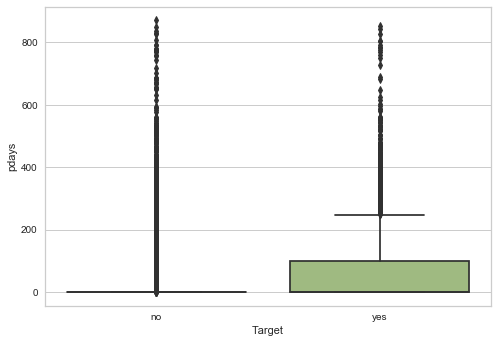

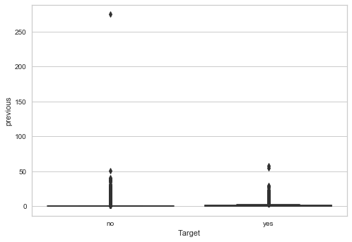

```python
for i in df.columns[df.dtypes!='category']:
    sns.boxplot(x='Target',y=i,data=df)
    plt.show()
```

The plots show age and day of the month are equally distributed in yes/no target. Also we can say duration of the call gets the chances of client deposit higher. Pdays and Previous show strong outlier behaviour.

```python
# Here we convert the columns that contain a Yes or No. (Binary Columns) to numeric for better plotting and analysis
def convert_to_int(df, new_column, target_column):
    df[new_column] = df[target_column].apply(lambda x: 0 if x == 'no' else 1)
    return df[new_column].value_counts()

convert_to_int(df, "Target_int", "Target") #Create a deposit int
convert_to_int(df, "housing_int", "housing") # Create housingint column
convert_to_int(df, "loan_int", "loan") #Create a loan_int column
convert_to_int(df, "default_int", "default") #Create a default_int column# Drop the binary columns and leave the same column in the form of integers 0 = No and 1 = Yes
```

```
0    44396
1      815
Name: default_int, dtype: int64
```

```python
df.drop(['housing', 'loan', 'default','Target'], axis=1, inplace=True)
df = df.rename(columns={"Target_int": "Target"})
df = df.rename(columns={"housing_int": "housing"})
df = df.rename(columns={"loan_int": "loan"})
df = df.rename(columns={"default_int": "default"})
```

```python
for i in ['Target','housing','loan','default']:
    df[i]=df[i].astype('int64')
df.info()
```

```
<class 'pandas.core.frame.DataFrame'>
RangeIndex: 45211 entries, 0 to 45210
Data columns (total 17 columns):
 #   Column     Non-Null Count  Dtype
---  ------     --------------  -----
 0   age        45211 non-null  int64
 1   job        45211 non-null  category
 2   marital    45211 non-null  category
 3   education  45211 non-null  category
 4   balance    45211 non-null  int64
 5   contact    45211 non-null  category
 6   day        45211 non-null  int64
 7   month      45211 non-null  category
 8   duration   45211 non-null  int64
 9   campaign   45211 non-null  int64
 10  pdays      45211 non-null  int64
 11  previous   45211 non-null  int64
 12  poutcome   45211 non-null  category
 13  Target     45211 non-null  int64
 14  housing    45211 non-null  int64
 15  loan       45211 non-null  int64
 16  default    45211 non-null  int64
dtypes: category(6), int64(11)
memory usage: 4.1 MB
```

## outliers Analysis

```python
Q1 = df_in.quantile(0.25)
Q3 = df_in.quantile(0.75)
IQR = Q3 - Q1
print(IQR)
```

```
age           15.0
balance     1356.0
day           13.0
duration     216.0
campaign       2.0
pdays          0.0
previous       0.0
dtype: float64
```

```python
df.shape
```

```
(45211, 17)
```

```python
np.where((df_in < (Q1 - 1.5 * IQR)) | (df_in > (Q3 + 1.5 * IQR)))
df_out = df_in[~((df_in < (Q1 - 1.5 * IQR)) |(df_in > (Q3 + 1.5 * IQR))).any(axis=1)] # rows without outliers
df_out.shape
```

```
(28193, 17)
```

There are huge number of data outside IQ threshhold and removing that or replacing add too much bias. so we don't do any treatment for outliers

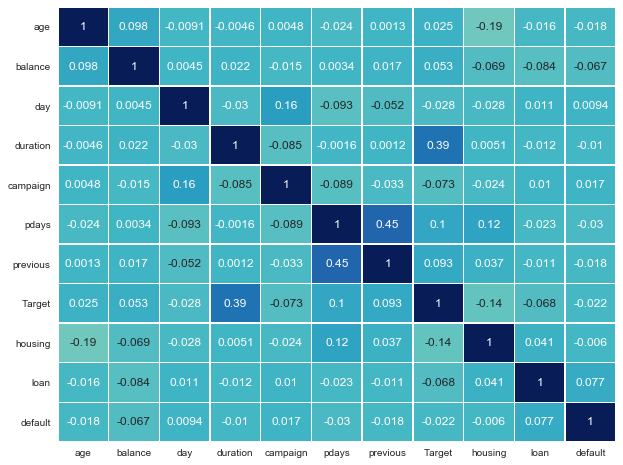

```python
plt.figure(figsize=(10,8))

sns.heatmap(df.corr(),
            annot=True,
            linewidths=.5,
            center=0,
            cbar=False,
            cmap="YlGnBu")

plt.show()
```

```python
#sns.pairplot(df, hue = 'target_int') #I couldn't plot because I didn't have the update libs and don't have admin acount to upload it
```

```python
df['Target'].value_counts(normalize='index')
```

```
0    0.883015
1    0.116985
Name: Target, dtype: float64
```

only 12 percent of clients accpeted to subscribe term deposit.

```python
pd.crosstab(df['job'],df['Target'],normalize='index')
```

| Target job | 0 | 1 |
| --- | --- | --- |
| admin. | 0.877973 | 0.122027 |
| blue-collar | 0.927250 | 0.072750 |
| entrepreneur | 0.917283 | 0.082717 |
| housemaid | 0.912097 | 0.087903 |
| management | 0.862444 | 0.137556 |
| retired | 0.772085 | 0.227915 |
| self-employed | 0.881571 | 0.118429 |
| services | 0.911170 | 0.088830 |
| student | 0.713220 | 0.286780 |
| technician | 0.889430 | 0.110570 |
| unemployed | 0.844973 | 0.155027 |
| unknown | 0.881944 | 0.118056 |

```python
pd.crosstab(df['marital'],df['Target'],normalize='index')
```

| Target marital | 0 | 1 |
| --- | --- | --- |
| divorced | 0.880545 | 0.119455 |
| married | 0.898765 | 0.101235 |
| single | 0.850508 | 0.149492 |

```python
pd.crosstab(df['education'],df['Target'],normalize='index')
```

| Target education | 0 | 1 |
| --- | --- | --- |
| primary | 0.913735 | 0.086265 |
| secondary | 0.894406 | 0.105594 |
| tertiary | 0.849936 | 0.150064 |
| unknown | 0.864297 | 0.135703 |

Clients accept term deposit have mostly Teritory education and/or single

```python
pd.crosstab(df['default'],df['Target'],normalize='index')
```

| Target default | 0 | 1 |
| --- | --- | --- |
| 0 | 0.882039 | 0.117961 |
| 1 | 0.936196 | 0.063804 |

```python
pd.crosstab(df['housing'],df['Target'],normalize='index')
```

| Target housing | 0 | 1 |
| --- | --- | --- |
| 0 | 0.832976 | 0.167024 |
| 1 | 0.923000 | 0.077000 |

```python
pd.crosstab(df['loan'],df['Target'],normalize='index')
```

| Target loan | 0 | 1 |
| --- | --- | --- |
| 0 | 0.873443 | 0.126557 |
| 1 | 0.933186 | 0.066814 |

```python
pd.crosstab(df['contact'],df['Target'],normalize='index')
```

| Target contact | 0 | 1 |
| --- | --- | --- |
| cellular | 0.850811 | 0.149189 |
| telephone | 0.865795 | 0.134205 |
| unknown | 0.959293 | 0.040707 |

```python
pd.crosstab(df['month'],df['Target'],normalize='index')
```

| Target month | 0 | 1 |
| --- | --- | --- |
| apr | 0.803206 | 0.196794 |
| aug | 0.889867 | 0.110133 |
| dec | 0.532710 | 0.467290 |
| feb | 0.833522 | 0.166478 |
| jan | 0.898788 | 0.101212 |
| jul | 0.909065 | 0.090935 |
| jun | 0.897772 | 0.102228 |
| mar | 0.480084 | 0.519916 |
| may | 0.932805 | 0.067195 |
| nov | 0.898489 | 0.101511 |
| oct | 0.562331 | 0.437669 |
| sep | 0.535406 | 0.464594 |

```python
pd.crosstab(df['poutcome'],df['Target'],normalize='index')
```

| Target poutcome | 0 | 1 |
| --- | --- | --- |
| failure | 0.873903 | 0.126097 |
| other | 0.833152 | 0.166848 |
| success | 0.352747 | 0.647253 |
| unknown | 0.908385 | 0.091615 |

```python
pd.crosstab(df['campaign'],df['Target'],normalize='index')
```

| Target campaign | 0 | 1 |
| --- | --- | --- |
| 1 | 0.854024 | 0.145976 |
| 2 | 0.887965 | 0.112035 |
| 3 | 0.888064 | 0.111936 |
| 4 | 0.909994 | 0.090006 |
| 5 | 0.921202 | 0.078798 |
| 6 | 0.928737 | 0.071263 |
| 7 | 0.936054 | 0.063946 |
| 8 | 0.940741 | 0.059259 |
| 9 | 0.935780 | 0.064220 |
| 10 | 0.947368 | 0.052632 |
| 11 | 0.920398 | 0.079602 |
| 12 | 0.974194 | 0.025806 |
| 13 | 0.954887 | 0.045113 |
| 14 | 0.956989 | 0.043011 |
| 15 | 0.952381 | 0.047619 |
| 16 | 0.974684 | 0.025316 |
| 17 | 0.913043 | 0.086957 |
| 18 | 1.000000 | 0.000000 |
| 19 | 1.000000 | 0.000000 |
| 20 | 0.976744 | 0.023256 |
| 21 | 0.971429 | 0.028571 |
| 22 | 1.000000 | 0.000000 |
| 23 | 1.000000 | 0.000000 |
| 24 | 0.950000 | 0.050000 |
| 25 | 1.000000 | 0.000000 |
| 26 | 1.000000 | 0.000000 |
| 27 | 1.000000 | 0.000000 |
| 28 | 1.000000 | 0.000000 |
| 29 | 0.937500 | 0.062500 |
| 30 | 1.000000 | 0.000000 |
| 31 | 1.000000 | 0.000000 |
| 32 | 0.888889 | 0.111111 |
| 33 | 1.000000 | 0.000000 |
| 34 | 1.000000 | 0.000000 |
| 35 | 1.000000 | 0.000000 |
| 36 | 1.000000 | 0.000000 |
| 37 | 1.000000 | 0.000000 |
| 38 | 1.000000 | 0.000000 |
| 39 | 1.000000 | 0.000000 |
| 41 | 1.000000 | 0.000000 |
| 43 | 1.000000 | 0.000000 |
| 44 | 1.000000 | 0.000000 |
| 46 | 1.000000 | 0.000000 |
| 50 | 1.000000 | 0.000000 |
| 51 | 1.000000 | 0.000000 |
| 55 | 1.000000 | 0.000000 |
| 58 | 1.000000 | 0.000000 |
| 63 | 1.000000 | 0.000000 |

## summary EDA

Campaign shows the more call for potential client gets lower chance of accepting the term deposit. A policy should be implemented that states that no more than 3 calls should be applied to the same potential client.

People working in Management, Blue-Collars and Technicians received the most offers from the marketing department to subscribe term deposits. However, students and retired tend to have more term deposits in order to gain some cash through interest payments.

Potential clients in the low balance and no balance category were more likely to have a house loan than people in the average and high balance category. So clients with no loan and no housing show more willing for term deposit since they are not concern with another payment.

Duration of the call shows high correlation since it might increase the level of engagement and transferring information to clients and they are more willing to subscribe for the term deposit.

# Deliverable – 2 (Prepare the data for analytics) – (10)

1. Ensure the attribute types are correct. If not, take appropriate actions.
2. Get the data model ready.
3. Transform the data i.e. scale / normalize if required
4. Create the training set and test set in ratio of 70:30

```python
from sklearn.preprocessing import StandardScaler
std_scale = StandardScaler()

X=df.drop('Target',axis=1)
Y=df['Target']
#Convert categorical vriables to dummy variables
# drop first means we get k-1 dummies out of k categorical levels by removing the first level for higher computational time.
X = pd.get_dummies(X,drop_first=True)
#Normalise integer variables
for i in X.columns[X.dtypes=='int64']:
    X[i]=std_scale.fit_transform(X[[i]])


X_train, X_test, y_train, y_test = train_test_split(X, Y, test_size=.3, random_state=22)

std_scale.fit_transform(X_train)
std_scale.transform(X_test)
X_train
```

|  | age | balance | day | duration | campaign | pdays | previous | housing | loan | default | ... | month_jul | month_jun | month_mar | month_may | month_nov | month_oct | month_sep | poutcome_other | poutcome_success | poutcome_unknown |
| --- | --- | --- | --- | --- | --- | --- | --- | --- | --- | --- | --- | --- | --- | --- | --- | --- | --- | --- | --- | --- | --- |
| 22411 | -0.464863 | -0.447419 | 0.744208 | -0.474374 | -0.246560 | -0.411453 | -0.251940 | -1.118674 | -0.436803 | -0.13549 | ... | 0 | 0 | 0 | 0 | 0 | 0 | 0 | 0 | 0 | 1 |
| 28589 | 0.382703 | -0.581093 | 1.585313 | 0.950731 | -0.246560 | 1.835679 | 7.562542 | 0.893915 | 2.289359 | -0.13549 | ... | 0 | 0 | 0 | 0 | 0 | 0 | 0 | 1 | 0 | 0 |
| 24461 | 0.006007 | -0.410634 | 0.143418 | 3.195173 | -0.569351 | 0.906864 | 0.182198 | 0.893915 | -0.436803 | -0.13549 | ... | 0 | 0 | 0 | 0 | 1 | 0 | 0 | 0 | 0 | 0 |
| 32766 | 0.947747 | -0.274005 | 0.143418 | 0.255653 | 0.076230 | -0.411453 | -0.251940 | 0.893915 | -0.436803 | -0.13549 | ... | 0 | 0 | 0 | 0 | 0 | 0 | 0 | 0 | 0 | 1 |
| 21336 | 0.665225 | -0.382061 | 0.263576 | -0.889867 | -0.246560 | -0.411453 | -0.251940 | -1.118674 | -0.436803 | -0.13549 | ... | 0 | 0 | 0 | 0 | 0 | 0 | 0 | 0 | 0 | 1 |
| ... | ... | ... | ... | ... | ... | ... | ... | ... | ... | ... | ... | ... | ... | ... | ... | ... | ... | ... | ... | ... | ... |
| 23030 | 0.006007 | -0.209303 | 1.224839 | 0.783757 | 2.335762 | -0.411453 | -0.251940 | -1.118674 | -0.436803 | -0.13549 | ... | 0 | 0 | 0 | 0 | 0 | 0 | 0 | 0 | 0 | 1 |
| 24932 | -0.464863 | -0.430669 | 0.263576 | 0.799289 | -0.569351 | -0.411453 | -0.251940 | 0.893915 | -0.436803 | -0.13549 | ... | 0 | 0 | 0 | 0 | 1 | 0 | 0 | 0 | 0 | 1 |
| 31680 | -0.559037 | -0.203063 | -1.058161 | 3.253420 | -0.569351 | -0.411453 | -0.251940 | 0.893915 | -0.436803 | -0.13549 | ... | 0 | 0 | 0 | 0 | 0 | 0 | 0 | 0 | 0 | 1 |
| 29484 | 0.194355 | -0.389286 | -1.538792 | -0.520971 | -0.569351 | -0.411453 | -0.251940 | -1.118674 | -0.436803 | -0.13549 | ... | 0 | 0 | 0 | 0 | 0 | 0 | 0 | 0 | 0 | 1 |
| 43893 | 3.678792 | 2.279914 | -0.817845 | 1.762303 | -0.569351 | 0.237718 | 4.957714 | -1.118674 | -0.436803 | -0.13549 | ... | 0 | 1 | 0 | 0 | 0 | 0 | 0 | 0 | 0 | 0 |

31647 rows × 42 columns

# Deliverable – 3 (create the ensemble model) – (30)

## First create models using Logistic Regression and Decision Tree algorithm. Note the model performance by using different matrices. Use confusion matrix to evaluate class level metrics i.e. Precision/Recall. Also reflect the accuracy and F1 score of the model. (10 marks)

```python
model=LogisticRegression(random_state=7,penalty='l1', solver='liblinear',C=1)
model.fit(X_train,y_train)  # fit the model on train data
y_predict=model.predict(X_test)
```

```python
z=pd.DataFrame()
z['probability that output is 1']=model.predict_proba(X_test)[:,1]
z['probability that output is 0']=model.predict_proba(X_test)[:,0]
z['predicted']=y_predict
z['observed']=y_test.values
z.head()
#In sklearn default threshold is 0.5
# therfore for all the values whose probability for 1 is greater than 0.5 will be predicted as 1
```

|  | probability that output is 1 | probability that output is 0 | predicted | observed |
| --- | --- | --- | --- | --- |
| 0 | 0.005612 | 0.994388 | 0 | 0 |
| 1 | 0.012986 | 0.987014 | 0 | 0 |
| 2 | 0.126406 | 0.873594 | 0 | 1 |
| 3 | 0.039736 | 0.960264 | 0 | 0 |
| 4 | 0.023780 | 0.976220 | 0 | 0 |

### model performance logistic regression

```python
#Store the accuracy results for each model in a dataframe for final comparison
acc = accuracy_score(y_test, model.predict(X_test))
recall=recall_score(y_test, model.predict(X_test))
precision=precision_score(y_test, model.predict(X_test))
F1score=f1_score(y_test,model.predict(X_test))
roc_auc=roc_auc_score(y_test, model.predict(X_test))

resultsDf = pd.DataFrame({'method':'Logistic Regression','prediction_accuracy':[acc],'recall': [recall],'precision': [precision],'F1score': [F1score], 'roc_auc_score': [roc_auc]})

resultsDf
```

|  | method | prediction_accuracy | recall | precision | F1score | roc_auc_score |
| --- | --- | --- | --- | --- | --- | --- |
| 0 | Logistic Regression | 0.899661 | 0.340038 | 0.634977 | 0.442898 | 0.657031 |

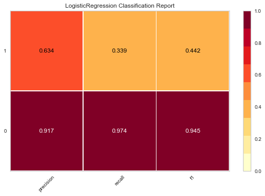

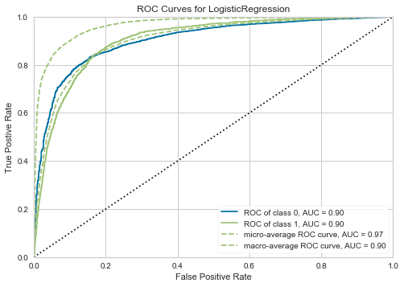

```python
# Visualize model performance with yellowbrick library
viz = ClassificationReport(LogisticRegression(random_state=7))
viz.fit(X_train, y_train)
viz.score(X_test, y_test)
viz.show()

roc = ROCAUC(LogisticRegression(random_state=7))
roc.fit(X_train, y_train)
roc.score(X_test, y_test)
roc.show()
```

## Decision tree analysis

```python
# invoking the decision tree classifier function. Using 'entropy' method of finding the split columns. Other option
# could be gini index.

model_entropy = DecisionTreeClassifier(criterion='entropy')
model_entropy.fit(X_train, y_train)
```

```
DecisionTreeClassifier(ccp_alpha=0.0, class_weight=None, criterion='entropy',
                       max_depth=None, max_features=None, max_leaf_nodes=None,
                       min_impurity_decrease=0.0, min_impurity_split=None,
                       min_samples_leaf=1, min_samples_split=2,
                       min_weight_fraction_leaf=0.0, presort='deprecated',
                       random_state=None, splitter='best')
```

```python
print("Train: %.2f" % model_entropy.score(X_train, y_train))  # performance on train data
print("Test: %.2f" % model_entropy.score(X_test, y_test))  # performance on test data
```

```
Train: 1.00
Test: 0.88
```

#### There is a high degree of overfitting in the model due to which the test accuracy drops drastically. This shows why decision trees are prone to overfitting. Regularize/prune the decision tree by limiting the max. depth of trees and print the accuracy.

```python
clf_pruned = DecisionTreeClassifier(criterion = "entropy", max_depth=4)
clf_pruned.fit(X_train, y_train)
```

```
DecisionTreeClassifier(ccp_alpha=0.0, class_weight=None, criterion='entropy',
                       max_depth=4, max_features=None, max_leaf_nodes=None,
                       min_impurity_decrease=0.0, min_impurity_split=None,
                       min_samples_leaf=1, min_samples_split=2,
                       min_weight_fraction_leaf=0.0, presort='deprecated',
                       random_state=None, splitter='best')
```

```python
print("Train: %.2f" % clf_pruned.score(X_train, y_train))  # performance on train data
print("Test: %.2f" % clf_pruned.score(X_test, y_test))  # performance on test data
```

```
Train: 0.90
Test: 0.90
```

```python
## Decision tree performance
# Confusion matrix
preds_train = clf_pruned.predict(X_train)
preds_test = clf_pruned.predict(X_test)
acc_DT = accuracy_score(y_test, preds_test)
pd.crosstab(y_test, preds_test, rownames=['Actual'], colnames=['Predicted'])
```

| Predicted Actual | 0 | 1 |
| --- | --- | --- |
| 0 | 11755 | 218 |
| 1 | 1148 | 443 |

```python
#Store the accuracy results for each model in a dataframe for final comparison
acc = accuracy_score(y_test, clf_pruned.predict(X_test))
recall=recall_score(y_test, clf_pruned.predict(X_test))
precision=precision_score(y_test, clf_pruned.predict(X_test))
F1score=f1_score(y_test,clf_pruned.predict(X_test))
roc_auc=roc_auc_score(y_test, clf_pruned.predict(X_test))

results = pd.DataFrame({'method':'Decision Tree','prediction_accuracy':[acc],'recall': [recall],'precision': [precision],'F1score': [F1score], 'roc_auc_score': [roc_auc]})

resultsDf = pd.concat([resultsDf, results])

resultsDf
```

|  | method | prediction_accuracy | recall | precision | F1score | roc_auc_score |
| --- | --- | --- | --- | --- | --- | --- |
| 0 | Logistic Regression | 0.899661 | 0.340038 | 0.634977 | 0.442898 | 0.657031 |
| 0 | Decision Tree | 0.899292 | 0.278441 | 0.670197 | 0.393428 | 0.630117 |

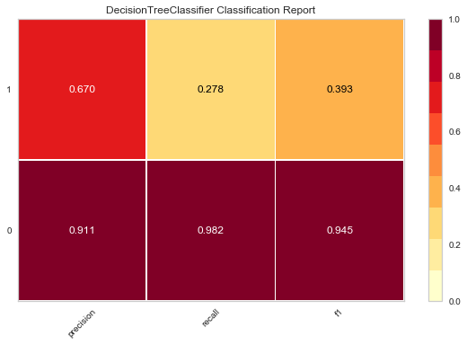

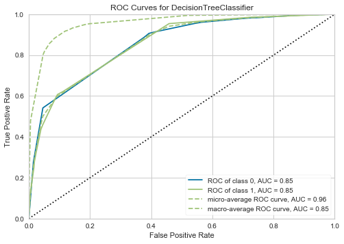

```python
# Visualize model performance with yellowbrick library
viz = ClassificationReport(DecisionTreeClassifier(criterion = "entropy", max_depth=4))
viz.fit(X_train, y_train)
viz.score(X_test, y_test)
viz.show()

roc = ROCAUC(DecisionTreeClassifier(criterion = "entropy", max_depth=4))
roc.fit(X_train, y_train)
roc.score(X_test, y_test)
roc.show()
```

#### Performance metrics

- **Precision**: Fraction of actuals per label that were correctly classified by the model
- **Recall**: Fraction of predictions that were correctly classified by the model
- **F1-score**: Weighted harmonic mean of the precision and recall. F1-score: 2 *(precision* recall) / (precision + recall)
- **Support**: Number of occurrences of each class in y_test
- **Accuracy**: Fraction of all observations that were correctly classified by the model
- **Macro avg**: Calculate metrics for each label, and find their unweighted mean. This does not take label imbalance into account
- **Micro/weighted avg**: Calculate metrics globally by counting the total true positives, false negatives and false positives
- **AUC Score**: Given a random observation from the dataset that belongs to a class, and a random observation that doesn't belong to a class, the AUC is the perecentage of time that our model will classify which is which correctly

The ROC curve tells us how well our classifier is classifying between term deposit suscriptions (True Positives) and non-term deposit suscriptions. The X-axis is represented by False positive rates (Specificity) and the Y-axis is represented by the True Positive Rate (Sensitivity.)

```python
## Calculating feature importance
features = [col for col in df.columns if col != 'Target']
feat_importance = clf_pruned.tree_.compute_feature_importances(normalize=False)


feat_imp_dict = dict(zip(features, clf_pruned.feature_importances_))
feat_imp = pd.DataFrame.from_dict(feat_imp_dict, orient='index')
feat_imp.sort_values(by=0, ascending=False)
```

|  | 0 |
| --- | --- |
| education | 0.590439 |
| month | 0.003469 |
| age | 0.000000 |
| job | 0.000000 |
| marital | 0.000000 |
| balance | 0.000000 |
| contact | 0.000000 |
| day | 0.000000 |
| duration | 0.000000 |
| campaign | 0.000000 |
| pdays | 0.000000 |
| previous | 0.000000 |
| poutcome | 0.000000 |
| housing | 0.000000 |
| loan | 0.000000 |
| default | 0.000000 |

## Ensemble technique

```python
### Apply the Random forest model and print the accuracy of Random forest Model
```

```python
from sklearn.ensemble import RandomForestClassifier
rfcl = RandomForestClassifier(n_estimators = 50)
rfcl = rfcl.fit(X_train, y_train)
pred_RF = rfcl.predict(X_test)
acc_RF = accuracy_score(y_test, pred_RF)
acc_RF
```

```
0.9052639339427897
```

```python
#Store the accuracy results for each model in a dataframe for final comparison
acc = accuracy_score(y_test, rfcl.predict(X_test))
recall=recall_score(y_test, rfcl.predict(X_test))
precision=precision_score(y_test, rfcl.predict(X_test))
F1score=f1_score(y_test, rfcl.predict(X_test))
roc_auc=roc_auc_score(y_test, rfcl.predict(X_test))

results = pd.DataFrame({'method':'Random Forest','prediction_accuracy':[acc],'recall': [recall],'precision': [precision],'F1score': [F1score], 'roc_auc_score': [roc_auc]})

resultsDf = pd.concat([resultsDf, results])

resultsDf
```

|  | method | prediction_accuracy | recall | precision | F1score | roc_auc_score |
| --- | --- | --- | --- | --- | --- | --- |
| 0 | Logistic Regression | 0.899661 | 0.340038 | 0.634977 | 0.442898 | 0.657031 |
| 0 | Decision Tree | 0.899292 | 0.278441 | 0.670197 | 0.393428 | 0.630117 |
| 0 | Random Forest | 0.905264 | 0.407291 | 0.654545 | 0.502131 | 0.689363 |

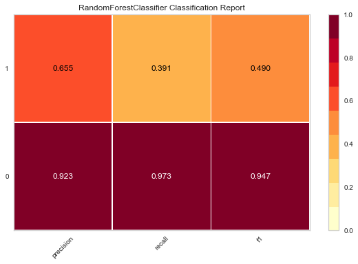

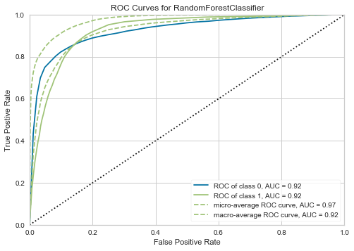

```python
# Visualize model performance with yellowbrick library
viz = ClassificationReport(RandomForestClassifier(n_estimators = 50))
viz.fit(X_train, y_train)
viz.score(X_test, y_test)
viz.show()

roc = ROCAUC(RandomForestClassifier(n_estimators = 50))
roc.fit(X_train, y_train)
roc.score(X_test, y_test)
roc.show()
```

## Apply Adaboost Ensemble Algorithm for the same data and print the accuracy.

```python
from sklearn.ensemble import AdaBoostClassifier
abcl = AdaBoostClassifier(n_estimators = 100, learning_rate=0.1, random_state=22)
abcl = abcl.fit(X_train, y_train)
```

```python
#Store the accuracy results for each model in a dataframe for final comparison
acc = accuracy_score(y_test, abcl.predict(X_test))
recall=recall_score(y_test, abcl.predict(X_test))
precision=precision_score(y_test, abcl.predict(X_test))
F1score=f1_score(y_test, abcl.predict(X_test))
roc_auc=roc_auc_score(y_test, abcl.predict(X_test))

results= pd.DataFrame({'method':'Adaboost','prediction_accuracy':[acc],'recall': [recall],'precision': [precision],'F1score': [F1score], 'roc_auc_score': [roc_auc]})

resultsDf = pd.concat([resultsDf, results])

resultsDf
```

|  | method | prediction_accuracy | recall | precision | F1score | roc_auc_score |
| --- | --- | --- | --- | --- | --- | --- |
| 0 | Logistic Regression | 0.899661 | 0.340038 | 0.634977 | 0.442898 | 0.657031 |
| 0 | Decision Tree | 0.899292 | 0.278441 | 0.670197 | 0.393428 | 0.630117 |
| 0 | Random Forest | 0.905264 | 0.407291 | 0.654545 | 0.502131 | 0.689363 |
| 0 | Adaboost | 0.895311 | 0.223759 | 0.658041 | 0.333959 | 0.604154 |

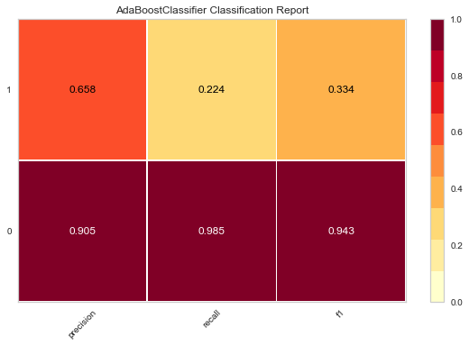

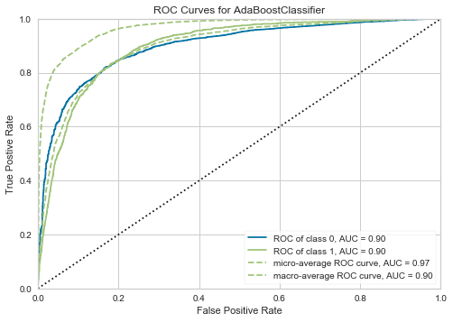

```python
# Visualize model performance with yellowbrick library
viz = ClassificationReport(AdaBoostClassifier(n_estimators= 100, learning_rate=0.1, random_state=22))
viz.fit(X_train, y_train)
viz.score(X_test, y_test)
viz.show()

roc = ROCAUC(AdaBoostClassifier(n_estimators= 100, learning_rate=0.1, random_state=22))
roc.fit(X_train, y_train)
roc.score(X_test, y_test)
roc.show()
```

### Apply Bagging Classifier Algorithm and print the accuracy.

```python
from sklearn.ensemble import BaggingClassifier

bgcl = BaggingClassifier(n_estimators=50, max_samples= .7, bootstrap=True, oob_score=True, random_state=22)
bgcl = bgcl.fit(X_train, y_train)
```

```python
#Store the accuracy results for each model in a dataframe for final comparison
train_acc=model.score(X_train,bgcl.predict(X_train))
test_acc=model.score(X_test, bgcl.predict(X_test))
acc = accuracy_score(y_test, bgcl.predict(X_test))
recall=recall_score(y_test, bgcl.predict(X_test))
precision=precision_score(y_test, bgcl.predict(X_test))
F1score=f1_score(y_test, bgcl.predict(X_test))
roc_auc=roc_auc_score(y_test, bgcl.predict(X_test))

results = pd.DataFrame({'method':'Bagging','prediction_accuracy':[acc],'recall': [recall],'precision': [precision],'F1score': [F1score], 'roc_auc_score': [roc_auc]})

resultsDf = pd.concat([resultsDf, results])

resultsDf
```

|  | method | prediction_accuracy | recall | precision | F1score | roc_auc_score |
| --- | --- | --- | --- | --- | --- | --- |
| 0 | Logistic Regression | 0.899661 | 0.340038 | 0.634977 | 0.442898 | 0.657031 |
| 0 | Decision Tree | 0.899292 | 0.278441 | 0.670197 | 0.393428 | 0.630117 |
| 0 | Random Forest | 0.905264 | 0.407291 | 0.654545 | 0.502131 | 0.689363 |
| 0 | Adaboost | 0.895311 | 0.223759 | 0.658041 | 0.333959 | 0.604154 |
| 0 | Bagging | 0.903200 | 0.458202 | 0.617797 | 0.526164 | 0.710267 |

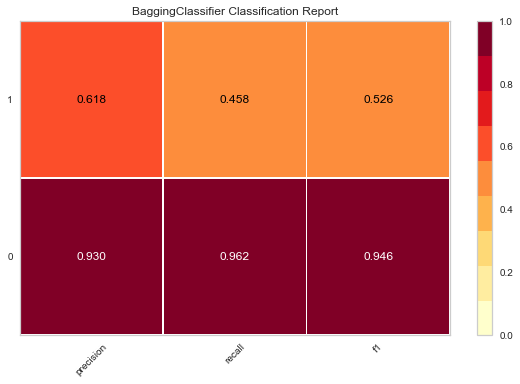

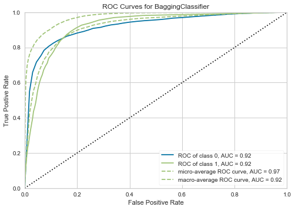

```python
# Visualize model performance with yellowbrick library
viz = ClassificationReport(BaggingClassifier(n_estimators=50, max_samples= .7, bootstrap=True, oob_score=True, random_state=22))
viz.fit(X_train, y_train)
viz.score(X_test, y_test)
viz.show()

roc = ROCAUC(BaggingClassifier(n_estimators=50, max_samples= .7, bootstrap=True, oob_score=True, random_state=22))
roc.fit(X_train, y_train)
roc.score(X_test, y_test)
roc.show()
```

### Apply GradientBoost Classifier Algorithm for the same data and print the accuracy

```python
from sklearn.ensemble import GradientBoostingClassifier
gbcl = GradientBoostingClassifier(n_estimators = 50, learning_rate = 0.1, random_state=22)
gbcl = gbcl.fit(X_train, y_train)
```

```python
#Store the accuracy results for each model in a dataframe for final comparison
train_acc=model.score(X_train,gbcl.predict(X_train))
test_acc=model.score(X_test, gbcl.predict(X_test))
acc = accuracy_score(y_test, gbcl.predict(X_test))
recall=recall_score(y_test, gbcl.predict(X_test))
precision=precision_score(y_test, gbcl.predict(X_test))
F1score=f1_score(y_test, gbcl.predict(X_test))
roc_auc=roc_auc_score(y_test, gbcl.predict(X_test))

results = pd.DataFrame({'method':'Gradient Boosting','prediction_accuracy':[acc],'recall': [recall],'precision': [precision],'F1score': [F1score], 'roc_auc_score': [roc_auc]})

resultsDf = pd.concat([resultsDf, results])

resultsDf
```

|  | method | prediction_accuracy | recall | precision | F1score | roc_auc_score |
| --- | --- | --- | --- | --- | --- | --- |
| 0 | Logistic Regression | 0.899661 | 0.340038 | 0.634977 | 0.442898 | 0.657031 |
| 0 | Decision Tree | 0.899292 | 0.278441 | 0.670197 | 0.393428 | 0.630117 |
| 0 | Random Forest | 0.905264 | 0.407291 | 0.654545 | 0.502131 | 0.689363 |
| 0 | Adaboost | 0.895311 | 0.223759 | 0.658041 | 0.333959 | 0.604154 |
| 0 | Bagging | 0.903200 | 0.458202 | 0.617797 | 0.526164 | 0.710267 |
| 0 | Gradient Boosting | 0.903716 | 0.364551 | 0.662857 | 0.470397 | 0.669956 |

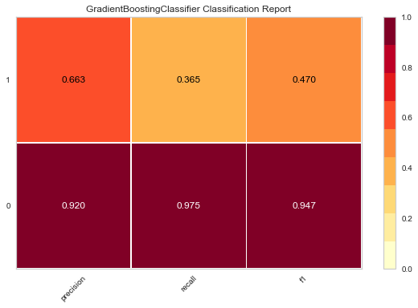

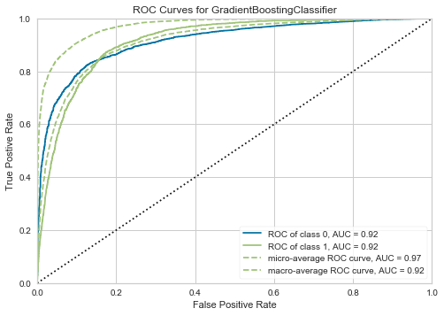

```python
# Visualize model performance with yellowbrick library
viz = ClassificationReport(GradientBoostingClassifier(n_estimators = 50, learning_rate = 0.1, random_state=22))
viz.fit(X_train, y_train)
viz.score(X_test, y_test)
viz.show()

roc = ROCAUC(GradientBoostingClassifier(n_estimators = 50, learning_rate = 0.1, random_state=22))
roc.fit(X_train, y_train)
roc.score(X_test, y_test)
roc.show()
```

## Make a DataFrame to compare models and their metrics. Give conclusion regarding the best algorithm and your reason behind it. (5 marks)

```python
resultsDf
```

|  | method | prediction_accuracy | recall | precision | F1score | roc_auc_score |
| --- | --- | --- | --- | --- | --- | --- |
| 0 | Logistic Regression | 0.899661 | 0.340038 | 0.634977 | 0.442898 | 0.657031 |
| 0 | Decision Tree | 0.899292 | 0.278441 | 0.670197 | 0.393428 | 0.630117 |
| 0 | Random Forest | 0.905264 | 0.407291 | 0.654545 | 0.502131 | 0.689363 |
| 0 | Adaboost | 0.895311 | 0.223759 | 0.658041 | 0.333959 | 0.604154 |
| 0 | Bagging | 0.903200 | 0.458202 | 0.617797 | 0.526164 | 0.710267 |
| 0 | Gradient Boosting | 0.903716 | 0.364551 | 0.662857 | 0.470397 | 0.669956 |

Confusion matrix meaning: True Positive (observed=1,predicted=1):

Predicted term deposit will be taken and the client accept it. or we can say the number of correctly classifications of the term deposit for potenial clients who are willing to suscribe a term deposit.

False Positive (observed=0,predicted=1):

Predicted term deposit will be taken and the client did not accept it

True Negative (observed=0,predicted=0):

Predicted term deposit will not be taken and the client did not accept it

False Negative (observed=1,predicted=0):

Predicted term deposit will not be taken and the client did accept it

Recall or sensitivity indicates the number of clients who were accepted the deposit rate and correctly identified. Recall ratio of the model is (TP/(TP+FN))) and Precision shows from the customers who predict to take the deposit term (TP+FP), how many were truly accepted that. (TP/(TP+FP)). As the precision gets higher the recall gets lower and vice versa. For instance, if we increase the precision from 30% to 60% the model is picking the predictions that the model believes is 60% sure. So it miss instances that are actually subscribe for deposit term. Here the suggestion is to have more focus on recall because marketing wants to increase the chances getting more and more clients. So they will not miss the customers who accept term deposit. On the other hand marketing wasn't susccefull in getting too many acceptance, it's better to increase the hit ratio.

Bagging model with a recall 0.45 and a fair precision , best F1 and best auc shows a good modeling approach. After achieving the desired accuracy we can deploy the model for practical use. As in the bank now can predict who will say yes for the deosit term. They can use the model for upcoming clients.